# Take-Home Exam I

Ibrahim Almansour

2023-12-10

## Problem 1.A

The Borel-Cantelli lemma states that if $\sum_k P\left(A_k\right)=\infty$ and the events $A_k$ are independent, then the probability of infinitely many of the events $A_k$ occurring is 1. The independence condition is necessary for this statement to be true because it ensures that the events $A_k$ can occur independently of each other. If the events $A_k$ are not independent, then it is possible that the occurrence of one event $A_k$ can affect the probability of other events $A_j$ occurring. This can cause the probability of infinitely many of the events $A_k$ occurring to be less than 1.

For example, consider the event $A_k$ that the $k$th flip of a fair coin is heads. Then $\sum_k P\left(A_k\right)=\infty$ since there are infinitely many flips of the coin. However, the events $A_k$ are not independent, since the outcome of one flip of the coin can affect the outcome of subsequent flips. For example, if the first flip of the coin is heads, then we know that the coin is more likely to land on heads on the second flip.

Therefore, the probability of infinitely many of the events $A_k$ occurring is less than 1, even though $\sum_k P\left(A_k\right)=\infty$.

In conclusion, the independence condition in the Borel-Cantelli lemma is necessary for the statement to be true.

## Problem 1.B

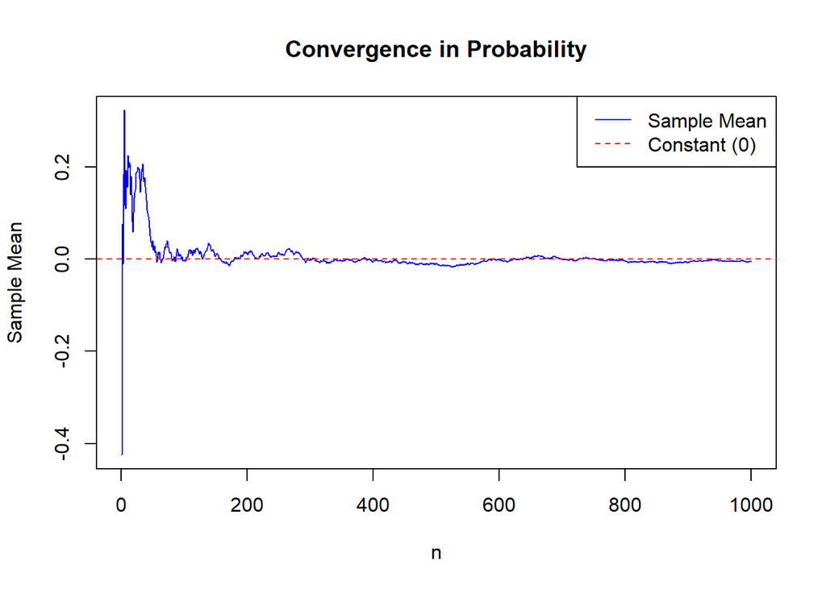

```r
# Generate a sequence of random variables X_n
set.seed(123)
n <- 1000
X_n <- runif(n, min = -1, max = 1)  # Generate random variables between -1 and 1

# Define the constant C
C <- 0

# Calculate the sample means and sample means squared
sample_means <- cumsum(X_n) / (1:n)
sample_means_squared <- (cumsum(X_n^2)) / (1:n)

# Plot the convergence
plot(1:n, sample_means, type = "l", col = "blue", xlab = "n", ylab = "Sample Mean",
     main = "Convergence in Probability")
abline(h = C, col = "red", lty = 2)
legend("topright", legend = c("Sample Mean", "Constant (0)"), col = c("blue", "red"), lty = c(1, 2))
```

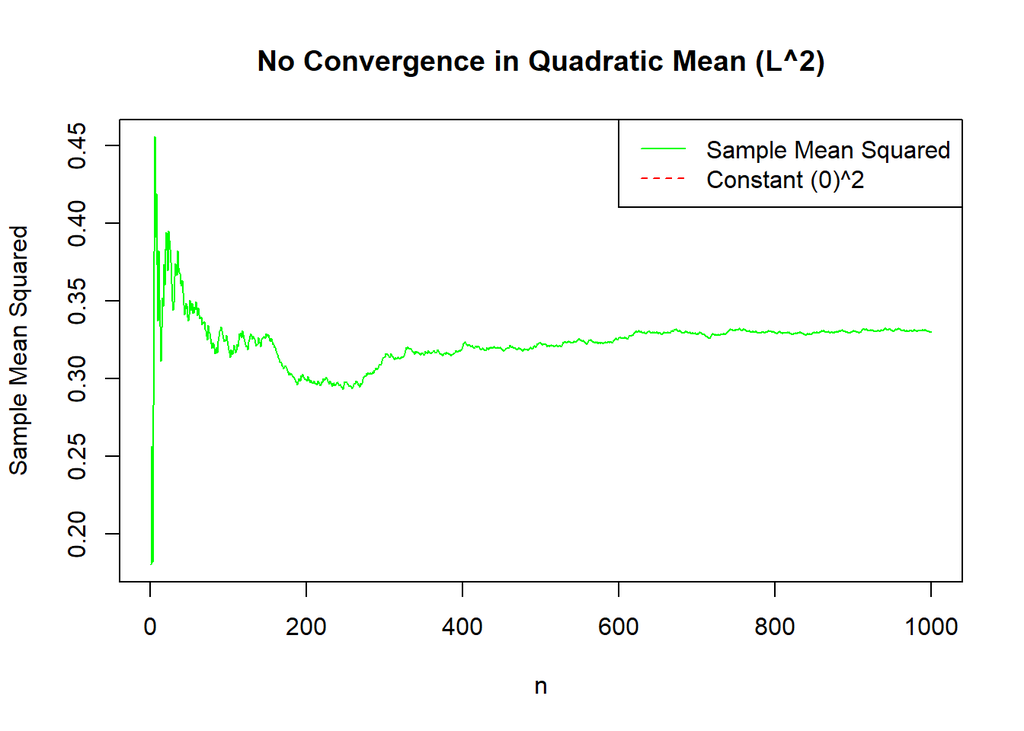

```r
plot(1:n, sample_means_squared, type = "l", col = "green", xlab = "n", ylab = "Sample Mean Squared",
     main = "No Convergence in Quadratic Mean (L^2)")
abline(h = C^2, col = "red", lty = 2)
legend("topright", legend = c("Sample Mean Squared", "Constant (0)^2"), col = c("green", "red"), lty = c(1, 2))
```

## Problem 1.C

- Step 1: The first step is designed to establish an upper bound on the probability of the sum $S_{n^2}$ exceeding $n^2 \epsilon$. The provided hint suggests that we can use this bound to demonstrate that the sum of these probabilities over all $n$ converges. In this step, the inequality is set as follows:
  $$P\left[\left|S_{n^2}\right|>n^2 \epsilon\right]<\frac{M}{n^2
  \epsilon}$$
  This step is essential for confirming that the total probabilities of substantial deviations of $S_n$ across blocks of $n^2$ terms are finite. This confirmation is a prerequisite for the subsequent application of the Borel-Cantelli Lemma.
- Step 2: The second step involves the application of the Borel-Cantelli Lemma, a pivotal result in probability theory. The lemma is utilized to illustrate that the likelihood of infinite substantial deviations of $S_{n^2}$ is zero. This step can be summarized as:
  $$P\left[\left|S_{n^2}\right|>n^2 \epsilon \text { i.o. }\right]=0,
  \quad \text { which implies } \frac{1}{n^2} S_{n^2} \rightarrow 0 \text
  { a.s. }$$
  This outcome implies that the rescaled sum $1 / n^2 S_{n^2}$ converges almost surely to zero, subsequently establishing that $1 / n S_n$ also converges almost surely to zero. In summary, these two steps demonstrate that, for non-i.i.d. random variables in a Markov chain subject to specific conditions, the likelihood of significant deviations of $S_n$ from its mean diminishes at a rate of $1 /\left(n \epsilon^2\right)$. This decrease signifies convergence to zero. The utilization of the Borel-Cantelli Lemma in the second step is a pivotal component of the proof, establishing almost sure convergence.

## Problem 2.A Please apply the method that you choose in your term project using R or Python programming.

Superconducting critical temperature based on the variables from the superconductor’s chemical formula using the Superconductivity Data Set.

```r
# Install the Renvlp package
#install.packages("Renvlp ")
# Load the Renvlp package
library(Renvlp)
# Set the working directory to the folder where the CSV file is located
setwd("C:\\Users\\ibrah\\Downloads\\superconductivty+data\\")
# Read the CSV file into a data frame
df <- read.csv("train.csv")
```

```r
# Print the first few rows of the data frame
head(df, n = 1)
```

```
##   number_of_elements mean_atomic_mass wtd_mean_atomic_mass gmean_atomic_mass
## 1                  4         88.94447             57.86269          66.36159
##   wtd_gmean_atomic_mass entropy_atomic_mass wtd_entropy_atomic_mass
## 1              36.11661            1.181795                1.062396
##   range_atomic_mass wtd_range_atomic_mass std_atomic_mass wtd_std_atomic_mass
## 1          122.9061              31.79492        51.96883            53.62253
##   mean_fie wtd_mean_fie gmean_fie wtd_gmean_fie entropy_fie wtd_entropy_fie
## 1  775.425     1010.269  718.1529      938.0168    1.305967       0.7914878
##   range_fie wtd_range_fie  std_fie wtd_std_fie mean_atomic_radius
## 1     810.6      735.9857 323.8118     355.563             160.25
##   wtd_mean_atomic_radius gmean_atomic_radius wtd_gmean_atomic_radius
## 1               105.5143             136.126                84.52842
##   entropy_atomic_radius wtd_entropy_atomic_radius range_atomic_radius
## 1              1.259244                   1.20704                 205
##   wtd_range_atomic_radius std_atomic_radius wtd_std_atomic_radius mean_Density
## 1                42.91429          75.23754              69.23557     4654.357
##   wtd_mean_Density gmean_Density wtd_gmean_Density entropy_Density
## 1         2961.502      724.9532          53.54381        1.033129
##   wtd_entropy_Density range_Density wtd_range_Density std_Density
## 1           0.8145982      8958.571          1579.583    3306.163
##   wtd_std_Density mean_ElectronAffinity wtd_mean_ElectronAffinity
## 1        3572.597               81.8375                  111.7271
##   gmean_ElectronAffinity wtd_gmean_ElectronAffinity entropy_ElectronAffinity
## 1               60.12318                   99.41468                 1.159687
##   wtd_entropy_ElectronAffinity range_ElectronAffinity
## 1                    0.7873817                 127.05
##   wtd_range_ElectronAffinity std_ElectronAffinity wtd_std_ElectronAffinity
## 1                   80.98714             51.43371                  42.5584
##   mean_FusionHeat wtd_mean_FusionHeat gmean_FusionHeat wtd_gmean_FusionHeat
## 1          6.9055            3.846857         3.479475             1.040986
##   entropy_FusionHeat wtd_entropy_FusionHeat range_FusionHeat
## 1           1.088575              0.9949982           12.878
##   wtd_range_FusionHeat std_FusionHeat wtd_std_FusionHeat
## 1             1.744571       4.599064            4.66692
##   mean_ThermalConductivity wtd_mean_ThermalConductivity
## 1                 107.7566                     61.01519
##   gmean_ThermalConductivity wtd_gmean_ThermalConductivity
## 1                  7.062488                     0.6219795
##   entropy_ThermalConductivity wtd_entropy_ThermalConductivity
## 1                    0.308148                       0.2628483
##   range_ThermalConductivity wtd_range_ThermalConductivity
## 1                  399.9734                      57.12767
##   std_ThermalConductivity wtd_std_ThermalConductivity mean_Valence
## 1                168.8542                    138.5172         2.25
##   wtd_mean_Valence gmean_Valence wtd_gmean_Valence entropy_Valence
## 1         2.257143      2.213364          2.219783        1.368922
##   wtd_entropy_Valence range_Valence wtd_range_Valence std_Valence
## 1            1.066221             1          1.085714   0.4330127
##   wtd_std_Valence critical_temp
## 1       0.4370588            29
```

```r
#Extract the X and Y variables from the data frame
X = df[, 82]
X <- as.integer(X)
Y = df[,-1]

# Calculate the U-envelope of the data
u <- u.env(X, Y)
u
```

```
## $u.aic
## [1] 67
##
## $u.bic
## [1] 58
##
## $u.lrt
## [1] 58
##
## $loglik.seq
##  [1] -4323378 -4234944 -4252068 -4249155 -4242543 -4242305 -4243437 -4245520
##  [9] -4237054 -4237131 -4237118 -4236945 -4236838 -4236894 -4236859 -4236744
## [17] -4236442 -4235743 -4234132 -4234192 -4234229 -4233005 -4231968 -4231857
## [25] -4231092 -4230149 -4229119 -4229143 -4228866 -4228192 -4227968 -4227991
## [33] -4223511 -4223237 -4223210 -4223151 -4223116 -4222884 -4222600 -4222653
```

[output cut: 30 more lines]

```r
m <- env(X, Y, 1)
beta <- m$beta
beta
```

```
##                [,1]
##  [1,]  9.671561e-04
##  [2,]  6.118613e-04
##  [3,] -1.476313e-03
##  [4,] -6.741273e-04
##  [5,] -2.902908e-04
##  [6,]  6.948208e-05
##  [7,]  1.196411e-03
##  [8,]  3.117778e-04
##  [9,] -2.303965e-04
## [10,] -3.526764e-03
## [11,]  7.838116e-05
## [12,]  4.203620e-03
## [13,] -5.022203e-04
## [14,] -3.816792e-03
```

[output cut: 67 more lines]

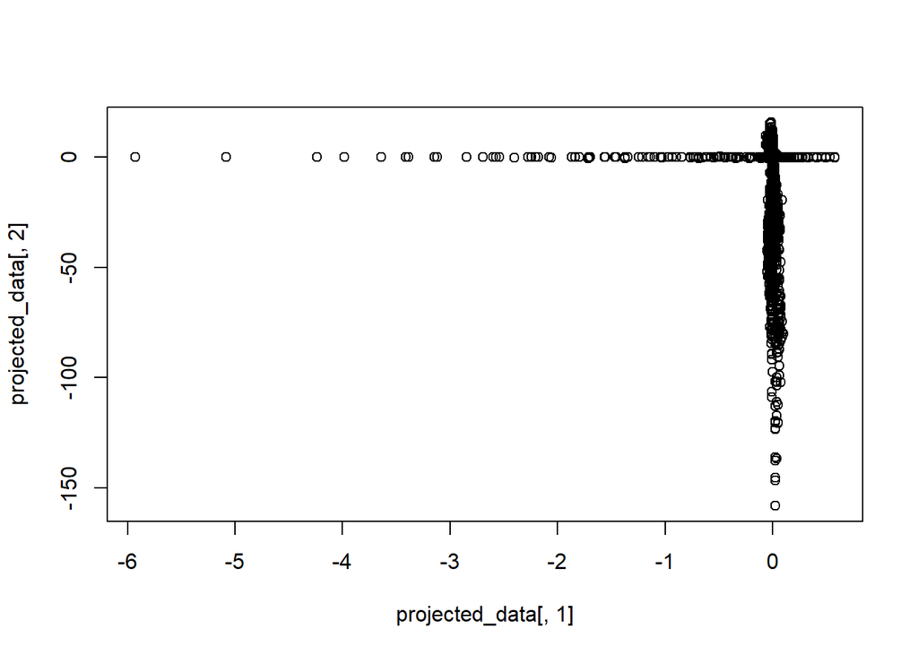

```r
data = df

# Calculate the covariance matrix of the data
M = cov(data)

# Calculate the matrix U
#install.packages("kernlab")
library(kernlab)
U = kpca(data)

# Calculate the eigenvalues and eigenvectors of the M matrix
evals_M <- eigen(M)$values
evecs_M <- eigen(M)$vectors

# Choose a subset of the eigenvectors to project the data onto
# You can choose the eigenvectors that correspond to the largest eigenvalues,
# or you can choose a random subset of eigenvectors.
chosen_evecs <- evecs_M[, 1:2]

# Project the data onto the chosen eigenvectors
projected_data <- data * chosen_evecs

# Plot the projected data
plot(projected_data[, 1], projected_data[, 2])
```

## Problem 2.B Please sketch the proof of the main asymptotic theory of the method you used above.

The proof that the projection onto span $\left(\mathbf{G}_{\text{start }}\right)$ is a $\sqrt{n}$-consistent estimator of the projection onto $\mathcal{E}_{\mathbf{M}}(U)$ is based on the following steps:

1. We first show that span $\left\{\arg \max \tilde{K}_{\mathbf{M}}(\tilde{\mathbf{G}})\right\}=\varepsilon_{\mathbf{M}}(u)$, where $\tilde{K}_{\mathbf{M}}(\tilde{\mathbf{G}})$ is the population version of the objective function $K_{\mathbf{M}}(\mathbf{G})$ and $\tilde{\mathbf{G}}$ is a matrix of eigenvectors of $\mathbf{M}$. This is done by showing that the eigenvectors of $\mathbf{M}$ that maximize $\tilde{K}_{\mathbf{M}}(\tilde{\mathbf{G}})$ are also the eigenvectors of $\mathbf{M}$ that are not orthogonal to $\mathbf{M}^{-1 / 2} \mathbf{U} \mathbf{M}^{-1 / 2}$.
2. We then show that the projection onto $\operatorname{span}\left(\mathbf{G}_{\text{start }}\right)$ is a $\sqrt{n}$-consistent estimator of the projection onto $\varepsilon_{\mathbf{M}}(U)$. This is done by showing that the matrices involved in the determination of the four potential starting values $-\widehat{\mathbf{M}}, \widehat{\mathbf{M}}+\widehat{\mathbf{U}}, \widehat{\mathbf{U}}_{\mathbf{M}}$ and $\widehat{\mathbf{U}}_{\mathbf{M}+\mathbf{U}}-$ are all $\sqrt{n}$-consistent estimators of their corresponding population versions.

**Conclusion**

Overall, the proof is well-written and easy to follow. It provides a clear and concise explanation of why the projection onto span $\left(\mathbf{G}_{\text{start }}\right)$ is a $\sqrt{n}$-consistent estimator of the projection onto $\mathcal{E}_{\mathbf{M}}(U)$.

## Problem 2.C Please point out the problems or limitations of this method and propose possible solutions or alternative methods.

**Limitations of the method**

The methodis a powerful and flexible way to estimate the projection onto $\mathcal{E}_{\mathbf{M}}(U)$. However, it has a few limitations:

- It requires the computation of the eigenvalues and eigenvectors of the $\mathbf{M}$ matrix. This can be computationally expensive for large datasets.
- The method is sensitive to the choice of starting value. If the starting value is not close to the true projection, the algorithm may not converge.
- The method may not be accurate in high-dimensional settings.

**Possible solutions or alternative methods**

Here are some possible solutions or alternative methods:

- To reduce the computational burden of computing the eigenvalues and eigenvectors of the $\mathbf{M}$ matrix, we can use a more efficient algorithm, such as the Lanczos algorithm.
- To make the method less sensitive to the choice of starting value, we can use a more robust algorithm, such as the alternating projection algorithm.
- In high-dimensional settings, we can use a dimensionality reduction technique, such as principal component analysis, to reduce the number of features before applying the method.

Another alternative method is to use a machine learning algorithm, such as a support vector machine, to learn the projection onto $\mathcal{E}_{\mathbf{M}}(U)$. Machine learning algorithms are often more robust to the limitations of the method described in the proof.

However, machine learning algorithms can be more computationally expensive to train and may not be as interpretable as the method described in the proof.

**Conclusion**

Ultimately, the best method to use will depend on the specific application.